# Assignment D

## Instructions

1. You may talk to a friend, discuss the questions and potential directions for solving them. However, you need to write your own solutions and code separately, and not as a group activity.
2. Write your code in the *Code* cells and your answer in the *Markdown* cells of the Jupyter notebook. Ensure that the solution is written neatly enough to understand and grade.
3. Use [Quarto](https://quarto.org/docs/output-formats/html-basics.html) to print the *.ipynb* file as HTML. You will need to open the command prompt, navigate to the directory containing the file, and use the command: `quarto render filename.ipynb --to html`. Submit the HTML file.
4. The assignment is worth 100 points, and is due on **Friday, 19th May 2023 at 11:59 pm**.
5. **Five points are properly formatting the assignment**. The breakdown is as follows:
- Must be an HTML file rendered using Quarto (2 pts).
- There aren’t excessively long outputs of extraneous information (e.g. no printouts of entire data frames without good reason, there aren’t long printouts of which iteration a loop is on, there aren’t long sections of commented-out code, etc.) (1 pt)
- Final answers of each question are written in Markdown cells (1 pt).
- There is no piece of unnecessary / redundant code, and no unnecessary / redundant text (1 pt)

```python
import pandas as pd
import numpy as np
import seaborn as sns
import matplotlib.pyplot as plt
from sklearn.metrics import mean_squared_error
from sklearn.model_selection import cross_val_score,train_test_split, KFold, cross_val_predict
from sklearn.metrics import mean_squared_error,r2_score,roc_curve,auc,precision_recall_curve, accuracy_score, \
recall_score, precision_score, confusion_matrix, mean_absolute_error
from sklearn.tree import DecisionTreeRegressor,DecisionTreeClassifier
from sklearn.model_selection import GridSearchCV, ParameterGrid, StratifiedKFold,RandomizedSearchCV
from sklearn.ensemble import BaggingRegressor,BaggingClassifier,AdaBoostRegressor,AdaBoostClassifier,GradientBoostingRegressor
from sklearn.linear_model import LinearRegression,LogisticRegression
from sklearn.neighbors import KNeighborsRegressor
import itertools as it
import time as time
import xgboost as xgb
```

## Conceptual

### AdaBoost vs Random Forest

Among AdaBoost and Random Forest, which model is more sensitive to outliers in response and why? Consider both regression and classification.

*(1 + 3 points)*

**AdaBoost is more sensitive to outliers when it pertains to both regression and classification. This is because the boosting algorithm will give higher weight to misclassified/more errant observations in future boosting iterations. As a result, the model might focus more on the outliers which leads to poor performance on the majority of the data.**

**Random Forest is more robust against outliers because it builds a large number of trees and takes a majority vote/averages the predictions. This can dampen the effect of outliers. Random Forests also use a random subset of features and observations in each tree which also helps reduce the effect of outliers.**

### Loss functions

Which loss functions should you use in boosting algorithms to reduce sensitivity to outliers in response, as compared to the squared error loss function, for regression problems. Name any 2 loss functions, and explain how they reduce the sensitivity towards outliers.

*(2 + 2 points)*

**1) Huber loss: this function combines the strenghts of MSE and MAE. For loss values less than a tuning parameter delta, we use the MSE and vice versa. Basically, for high loss values we use MAE which helps minimize outliers, and for lower loss values we use MSE which can give outliers some weight. This is a “best of both worlds” loss function that gives outliers some weight, but not too much. The delta parameter determines how sensitive you want to be to outliers.**

**2) L1/Absolute loss (MAE): This type of loss is not sensitive to outliers because it only involves the absolute difference between predicted and actual values.Thus, all of the errors will be weighted on the same linear scale. The loss function provides a generic and even measure of how well our model is performing.**

## Regression Problem - Miami housing

### Data preparation

Read the data *miami-housing.csv*. Check the description of the variables [here](https://www.kaggle.com/datasets/deepcontractor/miami-housing-dataset). Split the data into 60% train and 40% test. Use `random_state = 45`. The response is `SALE_PRC`, and the rest of the columns are predictors, except `PARCELNO`. Print the shape of the predictors dataframe of the train data.

*(2 points)*

```python
url = 'https://github.com/Dmjohnson4/Stat-303-3-Datasets/raw/main/miami-housing.csv'
housing = pd.read_csv(url)
X = housing.drop(columns = ['SALE_PRC','PARCELNO'], axis=1)
y = housing['SALE_PRC']

X_train, X_test, y_train, y_test = train_test_split(X, y, test_size=0.4, random_state=45)

print(X_train.shape)
```

```
(8359, 15)
```

**Shape: (8359, 15)**

### AdaBoost hyperparameter tuning

Develop and tune an AdaBoost model to predict `SALE_PRC` based on all the predictors. Compute the MAE on test data.

You must tune in the following manner:

1. Use `GridSearchCV` to minimize the $5$-fold mean absolute error (MAE).
2. You are advised to do a coarse grid search first to get an idea of the domain space where the optimal hyperparameter values lie.
3. If you reach the goal with the coarse grid search, you can stop. Otherwise, you may follow it up with a finer grid search to get more precise optimal hyperparameter values.
4. You may decide yourself which hyperparameters you wish to tune. Tuning `max_depth`, `n_estimators`, and `learning_rate` should suffice.

The test MAE must be less than **$46,000**. You must show the optimal values of the hyperparameters obtained, and the test MAE.

*Note: Hyperparameter tuning must be done on train data. Test data is only to assess model performance. Test data must remain untouched until the model is finalized, and must only be used to compute the test MAE.*

**Hint:** Below is one way to solve the problem. Note that there may be several completely different and better ways to solve the problem.

1. Consider tree depths of 3, 5, and 10, number of trees as 10, 50, 100, and 200, and learning rates as 0.0001, 0.001, 0.01, 0.1, and 1.0. `GridSearchCV` takes 2 minutes to execute on a 6-core laptop for these values.
2. With the above search, you will probably fail to achieve the objective. However, when you visualize the 5-fold MAE with each of the hyperparameter values considered, you will realize that there is a particular hyperparameter for which you should consider higher / lower values. You will also realize that you need not consider some of the values of the remaining hyperparameters.
3. Do another 2-minute grid search based on what you realized in (2), and you should achieve the objective.

*(10 points)*

```python
model = AdaBoostRegressor(random_state=1)
grid = dict()
grid['n_estimators'] = [250, 300]
grid['learning_rate'] = [0.1, 1.0]
grid['base_estimator'] = [DecisionTreeRegressor(max_depth=20),
                          DecisionTreeRegressor(max_depth=25)]

cv = KFold(n_splits=5, shuffle=True, random_state=1)

grid_search = GridSearchCV(estimator=model, param_grid=grid, n_jobs=-1, cv=cv, scoring='neg_mean_absolute_error')

grid_result = grid_search.fit(X_train, y_train)

print("Best: %f using %s" % (grid_result.best_score_, grid_result.best_params_))

means = grid_result.cv_results_['mean_test_score']
stds = grid_result.cv_results_['std_test_score']
params = grid_result.cv_results_['params']
```

```
Best: -44714.670377 using {'base_estimator': DecisionTreeRegressor(max_depth=25), 'learning_rate': 1.0, 'n_estimators': 300}
```

```python
y_pred = grid_result.best_estimator_.predict(X_test)

# calculate MAE
mean_absolute_error(y_test, y_pred)
```

```
45834.560912137094
```

**TEST MAE: 45834.560912137094**

### AdaBoost feature importance

Arrange and print the predictors in decreasing order of importance.

*(2 points)*

```python
importance = grid_result.best_estimator_.feature_importances_
feature_names = X_train.columns.tolist()


feature_importance = dict(zip(feature_names, importance))


sorted_features = sorted(feature_importance.items(), key=lambda x: x[1], reverse=True)


df = pd.DataFrame(columns=['Feature Name', 'Importance Score'])


for feature in sorted_features:
    df = df.append({'Feature Name': feature[0], 'Importance Score': feature[1]}, ignore_index=True)


df
```

|  | Feature Name | Importance Score |
| --- | --- | --- |
| 0 | TOT_LVG_AREA | 0.380755 |
| 1 | OCEAN_DIST | 0.171694 |
| 2 | CNTR_DIST | 0.072890 |
| 3 | LONGITUDE | 0.071616 |
| 4 | structure_quality | 0.065448 |
| 5 | WATER_DIST | 0.043509 |
| 6 | SPEC_FEAT_VAL | 0.037269 |
| 7 | SUBCNTR_DI | 0.031184 |
| 8 | RAIL_DIST | 0.031147 |
| 9 | LND_SQFOOT | 0.030460 |
| 10 | age | 0.027728 |
| 11 | LATITUDE | 0.015171 |
| 12 | HWY_DIST | 0.014696 |
| 13 | month_sold | 0.006328 |
| 14 | avno60plus | 0.000105 |

### Huber loss

What is the advantage of the Huber loss function *(page 349 of [Elements of Statistical Learning](https://hastie.su.domains/ElemStatLearn/printings/ESLII_print12_toc.pdf))* over the squared error and absolute error loss functions?

*(4 points)*

**The Huber loss function is more robust to outliers than squared error while also providing more efficient estimation for points close to the regression line than mean absolute error. Additionally, the Huber loss function is continous and differentiable unlike absolute error which is important for gradient algorithms. This loss function also has a tunable parameter that controls the balance between squared and absolute error. Overall, the advantage of Huber loss is that it provides a compromise betwen the squared error and absolute loss functions.**

### `RandomizedSearchCV` vs `GridSearchCV`

What’s the advantage of `GridSearchCV` over `RandomizedSearchCV` and vice-versa? When will `GridSearchCV` be preferred over `RandomizedSearchCV` and vice-versa?

*(4 points)*

**The main advantage of GridSearchCV is that is searches through all hyperparameters in the given space. If the search is well defined by the user, this method is guaranteed to find the optimal combination of hyperparameters. The main advantage of RandomizedSearchCV is that it is computationally more efficient than GridSearchCV because it randomly samples the hyperparameters from a given distribution.**

**GridSearchCV is preferred when the search space is small enough to not overwhelm computation resources. RandomizedSearchCV is preferred when the search space is large and/or computation resources are limited**

### Gradient boosting (Huber loss) hyperparameter tuning

Develop and tune a Gradient boosting model with `Huber` loss to predict `SALE_PRC` based on all the predictors. Compute the MAE on test data.

You must tune in the following manner:

1. Use may use `GridSearchCV` or `RandomizedSearchCV` to minimize the $K$-fold mean absolute error (MAE). You may choose any K.
2. You may decide yourself which hyperparameters you wish to tune. Tuning `max_depth`, `n_estimators`, `learning_rate`, and `subsample` should suffice.

The MAE must be less than **$43,000**. You must show the optimal values of the hyperparameters obtained, and the test MAE.

*Note: Hyperparameter tuning must be done on train data. Test data is only to assess model performance. Test data must remain untouched until the model is finalized, and must only be used to compute the test MAE.*

**Hint:** Below is one way to solve the problem. Note that there may be several completely different and better ways to solve the problem.

1. Use 2-fold cross-validation to make the execution speed higher. Here, we are compromising - adding bias to the CV error to get a lesser execution time.
2. In gradient boosting, the suggested depth of trees is in [4, 8] *(see page 363 in [Elements of Statistical Learning](https://hastie.su.domains/ElemStatLearn/printings/ESLII_print12_toc.pdf))*. So, consider depths of 4, 6, and 8. Consider 3 values of number of trees in [100, 1000], 3 values of learning rates in [0.01, 0.5], and 3 subsample values in [0.5, 1]. It takes 8 minutes on a 6-core laptop to do an exhaustive search on these values.
3. With the above search, you will probably fail to achieve the objective. However, when you compare the optimal hyperparameter values obtained with the hyperparameter values considered, you will realize that there are some hyperparameters for which you should consider higher / lower values.
4. Do another 10-minute grid search based on what you realized in (3), and you should achieve the objective.
5. Further fine-tuning may reduce your MAE to up to $42,400. However, you can stop once it is below \$43,000 in (4).

*(14 points)*

```python
model = GradientBoostingRegressor(random_state=1)
grid = dict()
grid['n_estimators'] = [2000, 2500]
grid['learning_rate'] = [0.007, 0.01, 0.012]
grid['max_depth'] = [7,8,9]
grid['subsample'] = [0.4,0.5,0.6]
# define the evaluation procedure
cv = StratifiedKFold(n_splits=2, shuffle=True, random_state=1)
# define the grid search procedure
grid_search = GridSearchCV(estimator=model, param_grid=grid, n_jobs=-1, cv=cv, verbose = True, scoring = 'neg_mean_absolute_error')
# execute the grid search
grid_result = grid_search.fit(X_train, y_train)
# summarize the best score and configuration
print("Best: %f using %s" % (grid_result.best_score_, grid_result.best_params_))
```

```
Fitting 2 folds for each of 54 candidates, totalling 108 fits
```

```
Best: -45369.806163 using {'learning_rate': 0.012, 'max_depth': 7, 'n_estimators': 2500, 'subsample': 0.4}
```

```python
model = GradientBoostingRegressor(max_depth=7,n_estimators=2500,learning_rate=0.012,subsample=0.4,
                         random_state=1,loss='huber').fit(X_train,y_train)
y_pred = model.predict(X_test)

mean_absolute_error(y_pred, y_test)
```

```
42867.92071252437
```

**TEST MAE: 42867.92071252437**

### Gradient boosting feature importance

Arrange and print the predictors in decreasing order of importance.

*(2 points)*

```python
importance = model.feature_importances_
feature_names = X_train.columns.tolist()


feature_importance = dict(zip(feature_names, importance))


sorted_features = sorted(feature_importance.items(), key=lambda x: x[1], reverse=True)


df = pd.DataFrame(columns=['Feature Name', 'Importance Score'])


for feature in sorted_features:
    df = df.append({'Feature Name': feature[0], 'Importance Score': feature[1]}, ignore_index=True)


df
```

|  | Feature Name | Importance Score |
| --- | --- | --- |
| 0 | TOT_LVG_AREA | 0.389208 |
| 1 | CNTR_DIST | 0.119395 |
| 2 | OCEAN_DIST | 0.099495 |
| 3 | SUBCNTR_DI | 0.082017 |
| 4 | structure_quality | 0.058183 |
| 5 | LONGITUDE | 0.051988 |
| 6 | LND_SQFOOT | 0.040646 |
| 7 | LATITUDE | 0.036845 |
| 8 | age | 0.032767 |
| 9 | SPEC_FEAT_VAL | 0.027311 |
| 10 | WATER_DIST | 0.022540 |
| 11 | HWY_DIST | 0.019302 |
| 12 | RAIL_DIST | 0.013115 |
| 13 | month_sold | 0.006719 |
| 14 | avno60plus | 0.000468 |

### Bias-variance

For each of the following hyperparameters tuned in the previous question, explain how do they effect the bias / variance of the model, when their values are increased.

#### `subsample`

*(8 points)*

**1) MAX_DEPTH: increasing this hyperparaneter decreases bias but increases variance. A higher max_depth allows models to fit more complex relationships and more accurately fit the training the data. This decreases bias but can lead to overfitting which increases variance.**

**2) N_ESTIMATORS: if n_estimators is insufficient, increasing this value can reduce the bias as it better captures the complexity of the data. Increasing n_estimators to a certain point can help reduce overfitting and improve the model’s generalization performance. Once n_estimators gets too high, not much is improved and only increases computational complexity.**

**3) LEARNING_RATE: Increasing this hyperparameter can increase the variance and decrease the bias of a model. A higher learning rate allows the model to learn more quickly and adapt to the training datawhich can lead to overfitting and higher variance but also lower bias.**

**4) SUBSAMPLE: increasing this value towards 1.0 increases variance and reduces bias. This is because a higher subsample value is less random and more prone to overfitting which increases variance. Bias is reduced because it uses more data and information from the training data set as subsample increases towards 1.0.**

### XGBoost objective function

How is XGboost different from gradient boosting performed with the `GradientBoostingRegressor()` function in the previous question with regard to the optimization objective? How does it benefit prediction accuracy with XGBoost?

*(4 points)*

### XGBoost hyperparameter tuning

Develop and tune an XGBoost model to predict `SALE_PRC` based on all the predictors. Compute the MAE on test data.

You must tune in the following manner:

1. Use may use `GridSearchCV` or `RandomizedSearchCV` to minimize the $K$-fold mean absolute error (MAE). You may choose any K.
2. You may decide yourself which hyperparameters you wish to tune. Tuning `max_depth`, `n_estimators`, `learning_rate`, `reg_lambda`, `gamma` and `subsample` should suffice.

The test MAE must be less than **$42,000**. You must show the optimal values of the hyperparameters obtained, and the test MAE.

*Note: Hyperparameter tuning must be done on train data. Test data is only to assess model performance. Test data must remain untouched until the model is finalized, and must only be used to compute the test MAE.*

**Hint:** Below is one way to solve the problem. Note that there may be several completely different and better ways to solve the problem.

1. Inspired by the optimal hyperparameter values obtained in [D.2.6](https://nustat.github.io/STAT303-3-class-notes/Assignment%20D.html#gradient-boosting-huber-loss-hyperparameter-tuning), do a search with 2-fold cross validation. Even though the default loss function in XGBoost is [`squarederror`](https://xgboost.readthedocs.io/en/stable/python/python_api.html#xgboost.XGBRegressor), hyperparameter values similar to the optimal hyperparameter values obtained in [D.2.6](https://nustat.github.io/STAT303-3-class-notes/Assignment%20D.html#gradient-boosting-huber-loss-hyperparameter-tuning) seem to work well. The regularization parameters `gamma` and `reg_lambda` help reduce RMSE further.
2. It took 10 minutes on a 6-core laptop to tune the model with (1), with the values of `gamma` considered as 0 and 10, and values of `reg_lambda` considered as 0, 1, and 10.

*(14 points)*

```python
model = xgb.XGBRegressor(random_state=1)

param_grid = {
    'max_depth': [7,12],
    'n_estimators': [5500],
    'learning_rate': [0.01, 0.1],
    'reg_lambda': [0, 1],
    'gamma': [0, 10],
    'subsample': [0.3,0.4]
}

cv = StratifiedKFold(n_splits=2, shuffle=True, random_state=1)
grid_search = RandomizedSearchCV(model, param_grid, n_iter=50, cv=cv, verbose=1, scoring='neg_mean_absolute_error', random_state=1)
grid_result = grid_search.fit(X_train, y_train)
print("Best: %f using %s" % (grid_result.best_score_, grid_result.best_params_))
```

```
Fitting 2 folds for each of 32 candidates, totalling 64 fits
Best: -45141.658210 using {'subsample': 0.4, 'reg_lambda': 1, 'n_estimators': 5500, 'max_depth': 7, 'learning_rate': 0.01, 'gamma': 0}
```

```python
xgb_model = xgb.XGBRegressor(max_depth=7, n_estimators=5500, learning_rate=0.01, subsample=0.4, gamma=0, reg_lambda=1, random_state=1)


xgb_model.fit(X_train, y_train)


y_pred = xgb_model.predict(X_test)


mean_absolute_error(y_test, y_pred)
```

```
41905.363175410464
```

**TEST MAE: 41905.363175410464**

### XGBoost Feature importance

Arrange and print the predictors in decreasing order of importance.

*(2 points)*

```python
importance = xgb_model.feature_importances_
feature_names = X_train.columns.tolist()


feature_importance = dict(zip(feature_names, importance))


sorted_features = sorted(feature_importance.items(), key=lambda x: x[1], reverse=True)


df = pd.DataFrame(columns=['Feature Name', 'Importance Score'])


for feature in sorted_features:
    df = df.append({'Feature Name': feature[0], 'Importance Score': feature[1]}, ignore_index=True)


df
```

|  | Feature Name | Importance Score |
| --- | --- | --- |
| 0 | structure_quality | 0.301493 |
| 1 | TOT_LVG_AREA | 0.210506 |
| 2 | OCEAN_DIST | 0.130560 |
| 3 | CNTR_DIST | 0.118244 |
| 4 | SUBCNTR_DI | 0.046450 |
| 5 | LONGITUDE | 0.042325 |
| 6 | WATER_DIST | 0.040186 |
| 7 | SPEC_FEAT_VAL | 0.021111 |
| 8 | age | 0.020905 |
| 9 | LND_SQFOOT | 0.017958 |
| 10 | RAIL_DIST | 0.014251 |
| 11 | LATITUDE | 0.010436 |
| 12 | HWY_DIST | 0.009807 |
| 13 | avno60plus | 0.008873 |
| 14 | month_sold | 0.006894 |

## Classification - Term deposit

The data for this question is related with direct marketing campaigns of a Portuguese banking institution. The marketing campaigns were based on phone calls, where bank clients were called to subscribe for a term deposit.

There is a train data - *train.csv*, which you will use to develop a model. There is a test data - *test1.csv* and *test2.csv*, which you will use to test your model. Each dataset has the following attributes about the clients called in the marketing campaign:

1. `age`: Age of the client
2. `education`: Education level of the client
3. `day`: Day of the month the call is made
4. `month`: Month of the call
5. `y`: did the client subscribe to a term deposit?
6. `duration`: Call duration, in seconds. This attribute highly affects the output target (e.g., if `duration`=0 then `y`=‘no’). Yet, the duration is not known before a call is performed. Also, after the end of the call `y` is obviously known. Thus, this input should only be included for inference purposes and should be discarded if the intention is to have a realistic predictive model.

(Raw data source: [Source](https://archive.ics.uci.edu/ml/datasets/bank+marketing). Do not use the raw data source for this assignment. It is just for reference.)

### Data preparation

Convert all the categorical predictors in the data to dummy variables. Note that `month` and `education` are categorical variables.

*(1 point)*

```python
train = pd.read_csv('train-5.csv')
test = pd.read_csv('test-2.csv')

train = train.drop(columns='duration')
test = test.drop(columns = 'duration')

train = pd.get_dummies(train, columns=['education', 'month'])
test = pd.get_dummies(test, columns=['education', 'month'])

train['y'] = train['y'].replace(['yes', 'no'], [1, 0])
test['y'] = test['y'].replace(['yes', 'no'], [1, 0])

X_train = train.drop(columns = 'y')
X_test = test.drop(columns = 'y')
y_train = train['y']
y_test = test['y']
```

### Boosting

Develop and tune any boosting model to predict the probability of a client subscribing to a term deposit based on `age`, `education`, `day` and `month`. The model must have:

1. **Minimum overall classification accuracy of 70%** among the classifcation accuracies on *train.csv*, and *test.csv*.
2. **Minimum recall of 65%** among the recall on *train.csv*, and *test.csv*.

Print the accuracy and recall for both the datasets - *train.csv*, and *test.csv*.

Note that:

1. You cannot use `duration` as a predictor. The predictor is not useful for prediction because its value is determined after the marketing call ends. However, after the call ends, we already know whether the client responded positively or negatively.
2. You are free to choose any value of threshold probability for classifying observations. However, you must use the same threshold on both the datasets.
3. Use cross-validation on train data to optimize the model hyperparameters.
4. Using the optimal model hyperparameters obtained in (iii), develop the decision tree model. Plot the cross-validated accuracy and recall against decision threshold probability. Tune the decision threshold probability based on the plot, or the data underlying the plot to achieve the required trade-off between recall and accuracy.
5. Evaluate the accuracy and recall of the developed model with the tuned decision threshold probability on both the datasets. Note that the test dataset must only be used to evaluate performance metrics, and not optimize any hyperparameters or decision threshold probability.

*(20 points - 10 points for tuning the hyperparameters, 4 points for making the plot, 4 points for tuning the decision threshold probability based on the plot, and 2 points for printing the accuracy & recall on both the datasets)*

It is up to you to pick the hyperparameters and their values in the grid.

**Hint:** Below is one way to solve the problem. Note that there may be several completely different and better ways to solve the problem.

XGBoost may help with tuning of `n_estimators`, `max_depth`, `learning_rate`, `gamma`, `reg_lambda`, and `subsample`. You may take the recommended value of [`scale_pos_weight`](https://xgboost.readthedocs.io/en/latest/parameter.html). Use `RandomizedSearchCV`. Evaluation of 200 models with 5-fold cross validation, i.e., 1000 fits, takes 45 minutes on a 6-core laptop. You may try a 2-fold cross validation to reduce time.

```python
scale_pos_weight = np.sum(y_train == 0) / np.sum(y_train == 1)

# Define the hyperparameters to tune and their search space
hyperparameters = {
    'n_estimators': range(100, 1000, 100),
    'max_depth': range(3, 12),
    'learning_rate': [0.2,0.4,0.6,0.8,1.0],
    'gamma': [0, 0.1, 0.5, 1],
    'reg_lambda': [0, 0.5, 1.0, 1.5, 2.0],
    'subsample': [0.4, 0.6, 0.8],
    'scale_pos_weight': [scale_pos_weight]
}

# Define the classifier
classifier = xgb.XGBClassifier(objective = 'binary:logistic',random_state=1,use_label_encoder=False)
cv = StratifiedKFold(n_splits=2,shuffle=True,random_state=1)
# Define the randomized search cv
rs_cv = RandomizedSearchCV(
    estimator=classifier,
    param_distributions=hyperparameters,
    cv=cv,
    scoring=['accuracy', 'recall'],
    refit='recall',
    n_iter=200,
    n_jobs=-1,
    verbose=2,
    random_state=1
)

# Fit the randomized search cv
grid_result = rs_cv.fit(X_train, y_train)
print("Best: %f using %s" % (grid_result.best_score_, grid_result.best_params_))
print("Best Accuracy Score: %f" % (grid_result.cv_results_['mean_test_accuracy'][grid_result.best_index_]))
print("Best Recall Score: %f" % (grid_result.cv_results_['mean_test_recall'][grid_result.best_index_]))
print("Best Hyperparameters: ", grid_result.best_params_)
```

[output not shown]

[output not shown]

[output cut: 18 more lines]

[output not shown]

[output cut: 19 more lines]

[output not shown]

[output cut: 66 more lines]

[output not shown]

[output cut: 35 more lines]

[output not shown]

[output cut: 40 more lines]

[output not shown]

[output cut: 19 more lines]

[output not shown]

[output cut: 16 more lines]

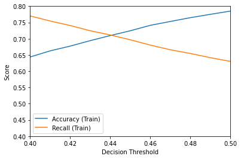

```python
model = xgb.XGBClassifier(objective='binary:logistic', use_label_encoder=False, max_depth=3, n_estimators=300, learning_rate=0.4, scale_pos_weight=scale_pos_weight, subsample=0.4, gamma=1, reg_lambda=2.0, random_state=1).fit(X_train, y_train)
y_pred_prob_train = model.predict_proba(X_train)[:, 1]

results_train = []

for threshold in np.arange(0.40, 0.51, 0.01):
    y_pred_train = (y_pred_prob_train > threshold).astype(int)
    accuracy_train = accuracy_score(y_train, y_pred_train)
    recall_train = recall_score(y_train, y_pred_train)
    results_train.append((threshold, accuracy_train, recall_train))

thresholds_train = [result[0] for result in results_train]
accuracies_train = [result[1] for result in results_train]
recalls_train = [result[2] for result in results_train]

plt.plot(thresholds_train, accuracies_train, label='Accuracy (Train)')
plt.plot(thresholds_train, recalls_train, label='Recall (Train)')
plt.xlabel('Decision Threshold')
plt.ylabel('Score')
plt.xlim(0.4, 0.5)
plt.ylim(0.4, 0.8)
plt.legend()
```

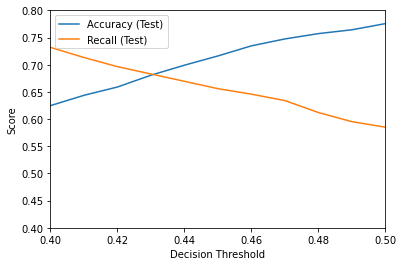

```python
model = xgb.XGBClassifier(objective='binary:logistic', use_label_encoder=False, max_depth=3, n_estimators=300, learning_rate=0.4, scale_pos_weight=scale_pos_weight, subsample=0.4, gamma=1, reg_lambda=2.0, random_state=1).fit(X_train, y_train)



results_test = []

for threshold in np.arange(0.40, 0.51, 0.01):
    y_pred_test = (model.predict_proba(X_test)[:, 1] > threshold).astype(int)
    accuracy_test = accuracy_score(y_test, y_pred_test)
    recall_test = recall_score(y_test, y_pred_test)
    results_test.append((threshold, accuracy_test, recall_test))

thresholds_test = [result[0] for result in results_test]
accuracies_test = [result[1] for result in results_test]
recalls_test = [result[2] for result in results_test]

plt.plot(thresholds_test, accuracies_test, label='Accuracy (Test)')
plt.plot(thresholds_test, recalls_test, label='Recall (Test)')
plt.xlabel('Decision Threshold')
plt.ylabel('Score')
plt.xlim(0.4, 0.5)
plt.ylim(0.4, 0.8)
plt.legend()
```

```python
scale_pos_weight = np.sum(y_train == 0) / np.sum(y_train == 1)

model = xgb.XGBClassifier(objective = 'binary:logistic', use_label_encoder=False, max_depth=3, n_estimators=300, learning_rate=0.4, scale_pos_weight=scale_pos_weight,subsample=0.4, gamma=1, reg_lambda=2.0, random_state=1).fit(X_train,y_train)


desired_threshold = 0.45

y_pred_prob_train = model.predict_proba(X_train)[:,1]
y_pred_train = y_pred_prob_train > desired_threshold
y_pred_train = y_pred_train.astype(int)
print("Train accuracy: ",accuracy_score(y_pred_train, y_train)*100)
print("Train recall: ", recall_score(y_train, y_pred_train)*100)


y_pred_prob_test = model.predict_proba(X_test)[:,1]
y_pred_test = y_pred_prob_test > desired_threshold
y_pred_test = y_pred_test.astype(int)
print("Test accuracy: ",accuracy_score(y_pred_test, y_test)*100)
print("Test recall: ", recall_score(y_test, y_pred_test)*100)
```

```
Train accuracy:  72.43714285714286
Train recall:  69.66374269005848
Test accuracy:  71.61025239679122
Test recall:  65.59865092748736
```